# VCA and Respo Plots

## Create models

- model breakdown:
- Fixed Effects = **log_silicate**: represents the linear relationship between the natural log of silicate and the response variable (Resp or umol) and **I(log_silicate^2)**: a quadratic effect of the log_silicate variable. By adding the square of log_silicate, you are testing whether there is a non-linear relationship between log_silicate and the response (Resp).
- Random Effects **new_colonynumber**: This is a random intercept for each new_colonynumber. Allows each colony to have its own baseline (intercept) while assuming that the slope of log_silicate and its quadratic term are the same across colonies. *The 1 signifies that only the intercept varies across levels of new_colonynumber* **date**: This term accounts for random variation by date. Each date can have its own random intercept to account for variation that occurs across different dates. **site**: This allows the model to account for site-specific differences by letting each site have its own random intercept.
- Also controlling for convergence behavior in the model fitting process
- **lmerControl** allows the model to ignore warnings about singular fits, which often arise when the random effects structure is too complex relative to the data (e.g., when there is insufficient variability among random effects). Basically don’t want the model to be overly sensitive
- Calculating the **R-squared value*: r-squared shows how well the data fit the regression model (the goodness of fit).
- Want to bootstrap WITH replacement
- Bootstrapping allows you to account for the variability in both fixed and random effects in a more nuanced way. This is especially important when random effects introduce a lot of variability into the model, as a single R-squared estimate may not fully capture how much variance each component explains. Also can help detect overfitting, have better generalization, and improve estimates of uncertainty.

```r
############################
# Respiration models
############################
## here the "tol = 1e-1000" extends the normal tolerance from its default of ~1000 to 10000000... which is dramatic, but wide enough to catch the smallest effect of site
modeltest_R <- lmer(Resp ~ log_silicate + I(log_silicate^2) + (1|new_colonynumber) + (1|date) + (1|site), data=PhysioRates_Wide,
                    control=lmerControl(check.conv.singular = .makeCC(action = "ignore",  tol = 1e-1000)))


anova(modeltest_R)
```

```
## Type III Analysis of Variance Table with Satterthwaite's method
##                     Sum Sq  Mean Sq NumDF  DenDF F value   Pr(>F)
## log_silicate      0.031516 0.031516     1 107.16 10.1926 0.001851 **
## I(log_silicate^2) 0.029059 0.029059     1 106.95  9.3981 0.002750 **
## ---
## Signif. codes:  0 '***' 0.001 '**' 0.01 '*' 0.05 '.' 0.1 ' ' 1
```

```r
summary(modeltest_R)
```

```
## Linear mixed model fit by REML. t-tests use Satterthwaite's method [
## lmerModLmerTest]
## Formula: Resp ~ log_silicate + I(log_silicate^2) + (1 | new_colonynumber) +
##     (1 | date) + (1 | site)
##    Data: PhysioRates_Wide
## Control: lmerControl(check.conv.singular = .makeCC(action = "ignore",
##     tol = 0))
##
## REML criterion at convergence: -313.9
##
## Scaled residuals:
##      Min       1Q   Median       3Q      Max
## -2.51450 -0.60214  0.02005  0.72220  2.46875
##
## Random effects:
##  Groups           Name        Variance  Std.Dev.
##  new_colonynumber (Intercept) 1.499e-04 1.224e-02
##  date             (Intercept) 4.624e-03 6.800e-02
##  site             (Intercept) 9.533e-11 9.764e-06
##  Residual                     3.092e-03 5.561e-02
## Number of obs: 121, groups:  new_colonynumber, 14; date, 7; site, 2
##
## Fixed effects:
##                    Estimate Std. Error        df t value Pr(>|t|)
## (Intercept)         0.53998    0.06967  92.70263   7.751 1.14e-11 ***
## log_silicate       -0.20361    0.06378 107.15654  -3.193  0.00185 **
## I(log_silicate^2)   0.04439    0.01448 106.95243   3.066  0.00275 **
## ---
## Signif. codes:  0 '***' 0.001 '**' 0.01 '*' 0.05 '.' 0.1 ' ' 1
##
## Correlation of Fixed Effects:
##             (Intr) lg_slc
## log_silicat -0.918
## I(lg_slc^2)  0.896 -0.991
```

```r
#check_model(modeltest_R) ## can uncomment if want to check model but when running markdown file, the plot screen is not big enough and prevents full knitting of script

## bootstrap to get the R2 values
r2_nakagawa(modeltest_R,iterations = 1000)
```

```
## # R2 for Mixed Models
##
##   Conditional R2: 0.624
##      Marginal R2: 0.044
```

```r
############################
# GP models
############################
modeltest_GP <- lmer(GP ~ log_silicate + I(log_silicate^2)+ (1|date) + (1|site)+(1|new_colonynumber), data=PhysioRates_Wide,
                     control=lmerControl(check.conv.singular = .makeCC(action = "ignore",  tol = 1e-1000)))

anova(modeltest_GP)
```

```
## Type III Analysis of Variance Table with Satterthwaite's method
##                   Sum Sq Mean Sq NumDF  DenDF F value   Pr(>F)
## log_silicate      0.1768  0.1768     1 110.54 10.3450 0.001703 **
## I(log_silicate^2) 0.1521  0.1521     1 110.42  8.8999 0.003511 **
## ---
## Signif. codes:  0 '***' 0.001 '**' 0.01 '*' 0.05 '.' 0.1 ' ' 1
```

```r
summary(modeltest_GP)
```

```
## Linear mixed model fit by REML. t-tests use Satterthwaite's method [
## lmerModLmerTest]
## Formula: GP ~ log_silicate + I(log_silicate^2) + (1 | date) + (1 | site) +
##     (1 | new_colonynumber)
##    Data: PhysioRates_Wide
## Control: lmerControl(check.conv.singular = .makeCC(action = "ignore",
##     tol = 0))
##
## REML criterion at convergence: -114.1
##
## Scaled residuals:
##     Min      1Q  Median      3Q     Max
## -2.9782 -0.5873  0.1088  0.6328  3.3597
##
## Random effects:
##  Groups           Name        Variance  Std.Dev.
##  new_colonynumber (Intercept) 6.046e-03 7.775e-02
##  date             (Intercept) 1.338e-03 3.658e-02
##  site             (Intercept) 8.773e-11 9.366e-06
##  Residual                     1.709e-02 1.307e-01
## Number of obs: 121, groups:  new_colonynumber, 14; date, 7; site, 2
##
## Fixed effects:
##                    Estimate Std. Error        df t value Pr(>|t|)
## (Intercept)         1.23927    0.15125 110.11493   8.194 5.03e-13 ***
## log_silicate       -0.47334    0.14717 110.53870  -3.216  0.00170 **
## I(log_silicate^2)   0.09989    0.03348 110.41836   2.983  0.00351 **
## ---
## Signif. codes:  0 '***' 0.001 '**' 0.01 '*' 0.05 '.' 0.1 ' ' 1
##
## Correlation of Fixed Effects:
##             (Intr) lg_slc
## log_silicat -0.975
## I(lg_slc^2)  0.950 -0.991
```

```r
#check_model(modeltest_GP)
r2_nakagawa(modeltest_GP,iterations = 1000)
```

```
## # R2 for Mixed Models
##
##   Conditional R2: 0.360
##      Marginal R2: 0.084
```

```r
############################
# C models
############################
modeltest_C <- lmer(C ~ log_silicate  + (1|new_colonynumber) + (1|date) + (1|site), data=PhysioRates_Wide,
                    control=lmerControl(check.conv.singular = .makeCC(action = "ignore",  tol = 1e-1000)))

anova(modeltest_C)
```

```
## Type III Analysis of Variance Table with Satterthwaite's method
##                Sum Sq  Mean Sq NumDF  DenDF F value  Pr(>F)
## log_silicate 0.021962 0.021962     1 107.57  4.2771 0.04103 *
## ---
## Signif. codes:  0 '***' 0.001 '**' 0.01 '*' 0.05 '.' 0.1 ' ' 1
```

```r
summary(modeltest_C)
```

```
## Linear mixed model fit by REML. t-tests use Satterthwaite's method [
## lmerModLmerTest]
## Formula: C ~ log_silicate + (1 | new_colonynumber) + (1 | date) + (1 |
##     site)
##    Data: PhysioRates_Wide
## Control: lmerControl(check.conv.singular = .makeCC(action = "ignore",
##     tol = 0))
##
## REML criterion at convergence: -250.2
##
## Scaled residuals:
##     Min      1Q  Median      3Q     Max
## -2.1547 -0.5319 -0.0199  0.5042  3.2034
##
## Random effects:
##  Groups           Name        Variance Std.Dev.
##  new_colonynumber (Intercept) 0.005788 0.07608
##  date             (Intercept) 0.000000 0.00000
##  site             (Intercept) 0.000000 0.00000
##  Residual                     0.005135 0.07166
## Number of obs: 121, groups:  new_colonynumber, 14; date, 7; site, 2
##
## Fixed effects:
##               Estimate Std. Error        df t value Pr(>|t|)
## (Intercept)    0.13988    0.02993  44.63299   4.673 2.74e-05 ***
## log_silicate  -0.02255    0.01090 107.56991  -2.068    0.041 *
## ---
## Signif. codes:  0 '***' 0.001 '**' 0.01 '*' 0.05 '.' 0.1 ' ' 1
##
## Correlation of Fixed Effects:
##             (Intr)
## log_silicat -0.701
```

```r
#check_model(modeltest_C)
r2_nakagawa(modeltest_C,iterations = 1000)
```

```
## Random effect variances not available. Returned R2 does not account for random effects.
```

```
## # R2 for Mixed Models
##
##   Conditional R2: NA
##      Marginal R2: 0.037
```

## Create VCAs

### What is variance component analysis (VCA)?

- A VCA is a statistical method used to determine how much of the **total** variance in a **dependent** variable can be attributed to different sources of *random variation*
- Typically within a mixed effects model
- Breaks down the total variance into components related to different random effects in the study design
- VCA are a way to assess how the variability of a dependent variable is structured taking into account its association with one or multiple random-effects variables

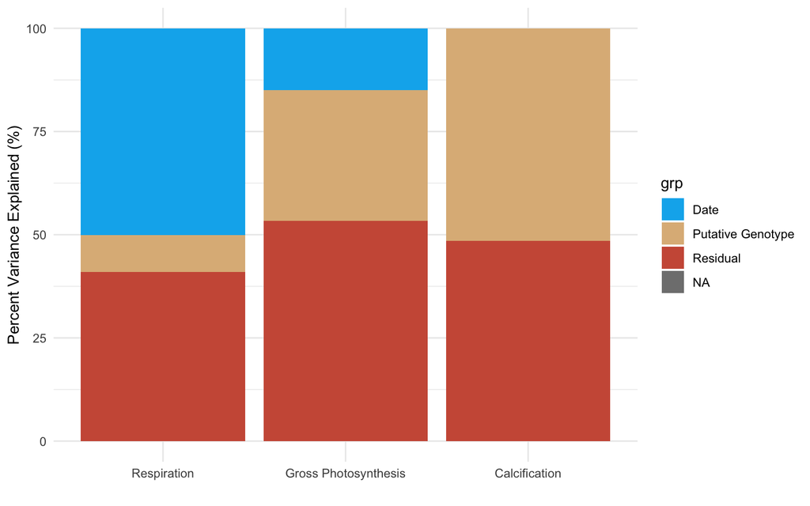

```r
# get the variance components manually for respiration
R_var<-as_tibble(summary(modeltest_R)$varcor) # extract the variance

R_var<-R_var %>%
  mutate(percentvar_R = 100*sdcor/sum(sdcor)) %>% # calculate variance explained by each random effect and label in own column
  dplyr::select(grp, percentvar_R) # only select what I need

# get the variance components manually for gross photosynthesis
GP_var<-as_tibble(summary(modeltest_GP)$varcor)

GP_var<-GP_var %>%
  mutate(percentvar_GP = 100*sdcor/sum(sdcor))%>% #
  dplyr::select(grp, percentvar_GP)

# get the variance components manually for calcification
C_var<-as_tibble(summary(modeltest_C)$varcor)

C_var<-C_var %>%
  mutate(percentvar_Cr = 100*sdcor/sum(sdcor)) %>%
  dplyr::select(grp, percentvar_Cr)

#################
# bring them all together
# plot the VCA results
#################

variance_plot <- R_var %>%
  left_join(GP_var)%>%
  left_join(C_var) %>%
  pivot_longer(cols = percentvar_R:percentvar_Cr) %>% # pivot to orient for a barplot
  mutate(nicenames = case_when(name == "percentvar_R" ~ "Respiration",
                               name == "percentvar_GP" ~ "Gross Photosynthesis",
                               name == "percentvar_Cr" ~ "Calcification"))%>%
  mutate(grp = case_when(grp == "new_colonynumber"~ "Putative Genotype",
                          grp == "date"~ "Date",
                          grp == "site"~ "Source Water",
                         grp == "Residual"~ "Residual")) %>%
  mutate(grp = factor(grp, levels = c("Site","Date","Putative Genotype","Residual"))) %>% # put the levels in an order I want for plotting
  ggplot(aes(x = nicenames,
             y = value,
             fill = grp))+
  geom_bar(stat = "identity") +
  labs(x = "",
       y = "Percent Variance Explained (%)") +
  theme(axis.text = element_text(size = 14),
        axis.title = element_text(size = 14, color="black"),
        legend.text = element_text(size = 14, color="black")) +
  theme_minimal() +
  scale_x_discrete(limits = c("Respiration", "Gross Photosynthesis", "Calcification")) +
  scale_fill_manual(values=c("deepskyblue2", "burlywood", "coral3", "gray"))
variance_plot
```

```r
ggsave(here::here("Outputs", "PaperFigures", "VCA.jpg"),
       width=12, height=10)
```

# New R, GP, and C plots based on updated models

- Random effect of site

## Standardized effect plots

- **what is a standardized effect plot?**
- visually compare which predictors have the strongest and weakest effects on the response variable, regardless of the units or scales of the predictors
- In regression, predictors may have different units. To compare their relative impact, we standardize both the predictors and response. This is done by converting them to z-scores, meaning that they have a mean of 0 and a standard deviation of 1. The resulting coefficients (effect sizes) are then expressed in terms of standard deviations, allowing for direct comparison.
- None of the effects cross 0 so they are all significant, BUT not from each other because the error bars overlap. The linear effect of silicate is negative on all three physio rates, with the smallest effect on calcification. Although, there is no statistical significant difference between the effect of silicate on C, GP, and R. But the quadratic effect of silicate is positive on GP and R, though the intercept is virtually the same for both.

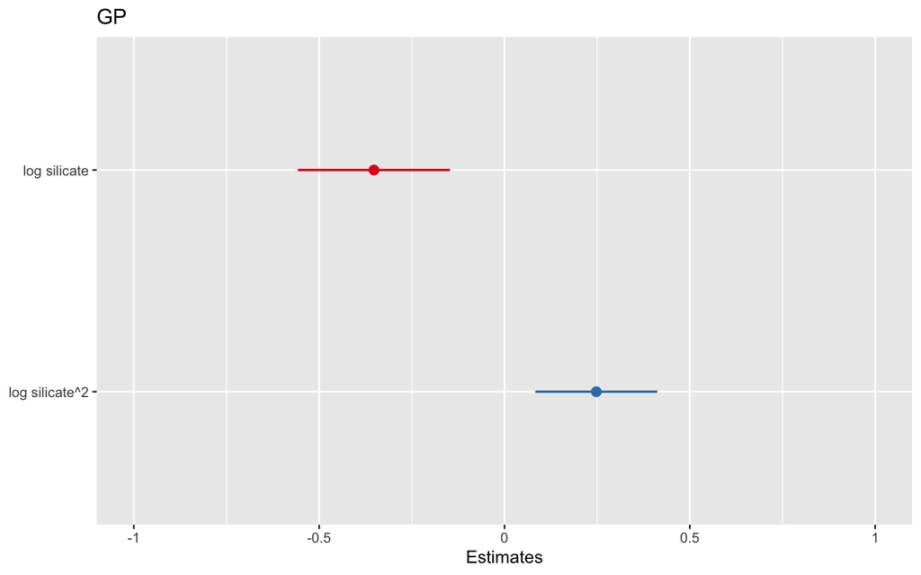

```r
###############################
# standardized effect size plots
###############################
plot_model(modeltest_GP, type = "std") # gives standardized effect sizes
```

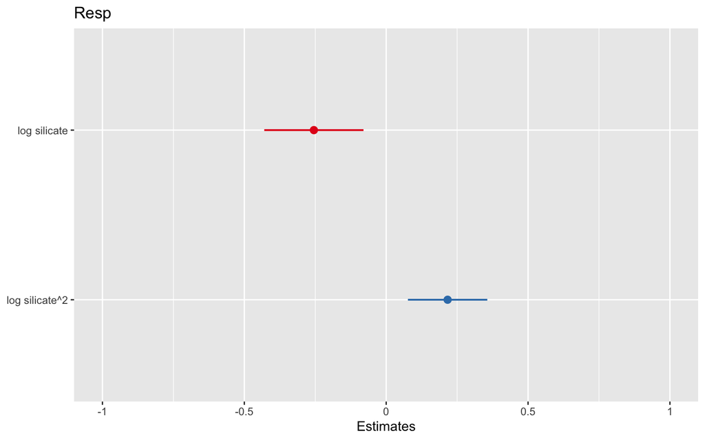

```r
plot_model(modeltest_R, type = "std")
```

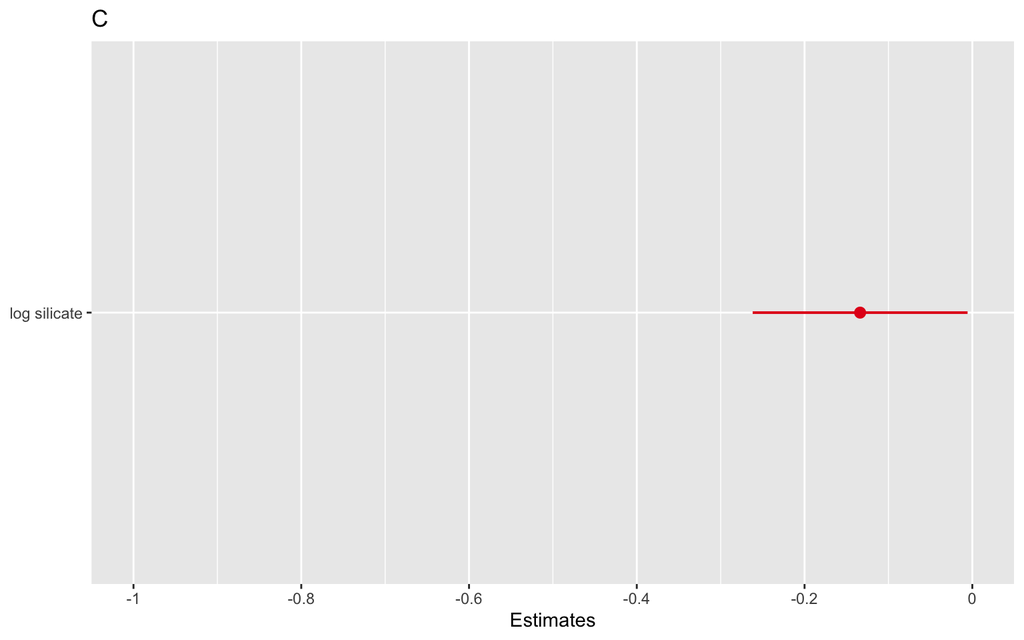

```r
plot_model(modeltest_C, type = "std")
```

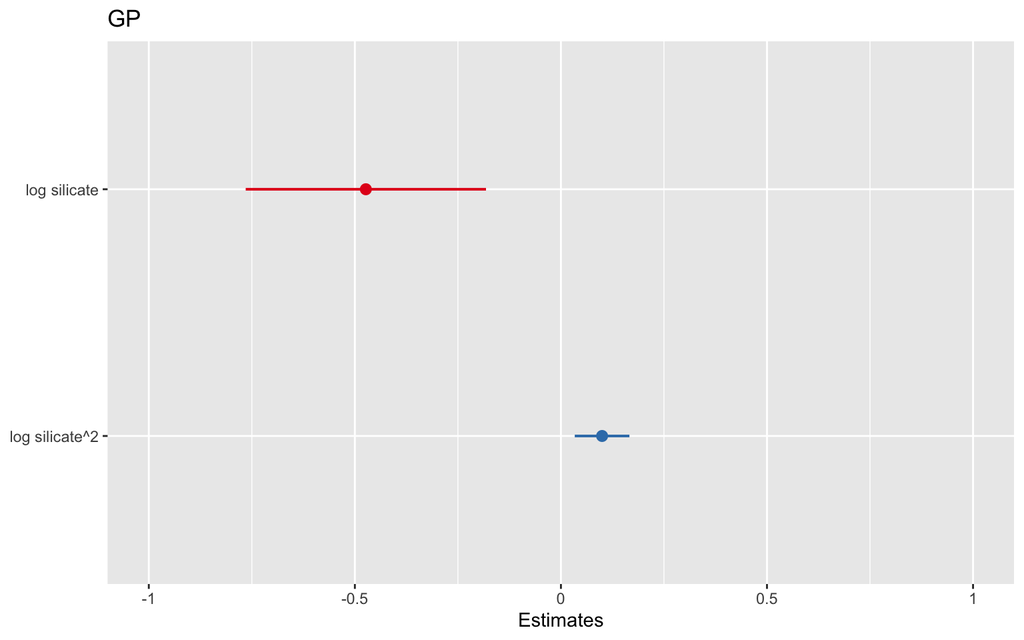

```r
###############################
## testing withOUT standardized effect sizes to see comparison
###############################
plot_model(modeltest_GP)
```

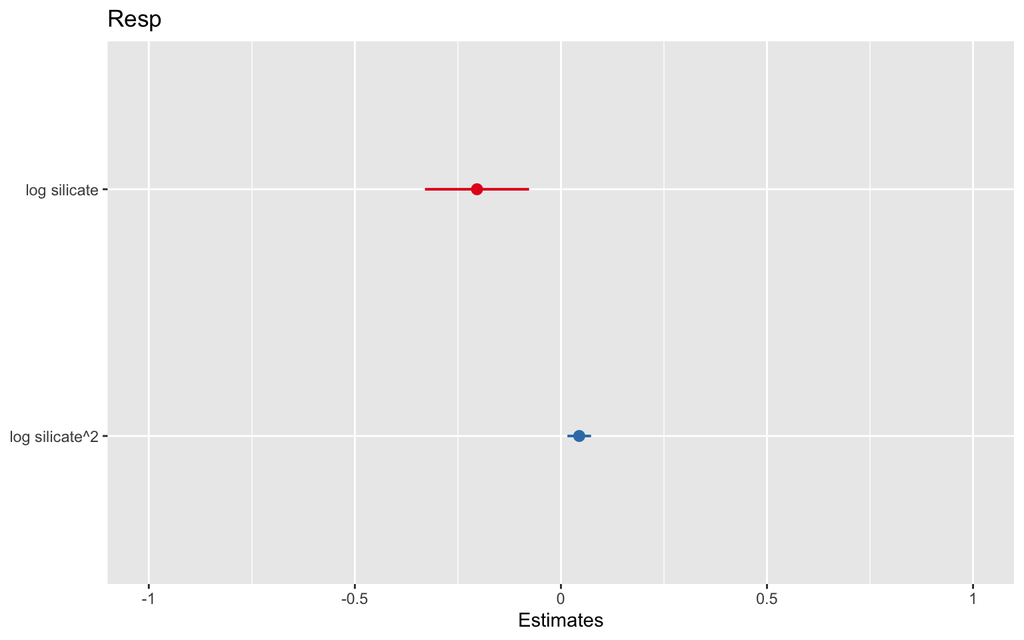

```r
plot_model(modeltest_R)
```

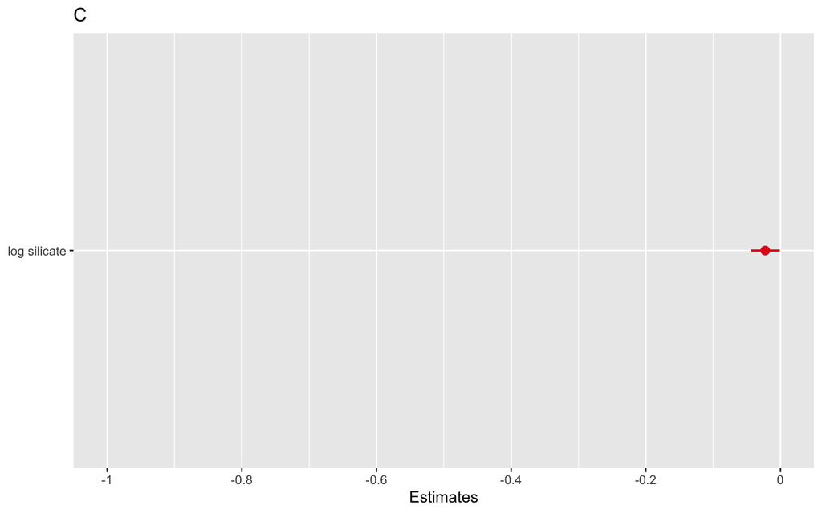

```r
plot_model(modeltest_C)
```

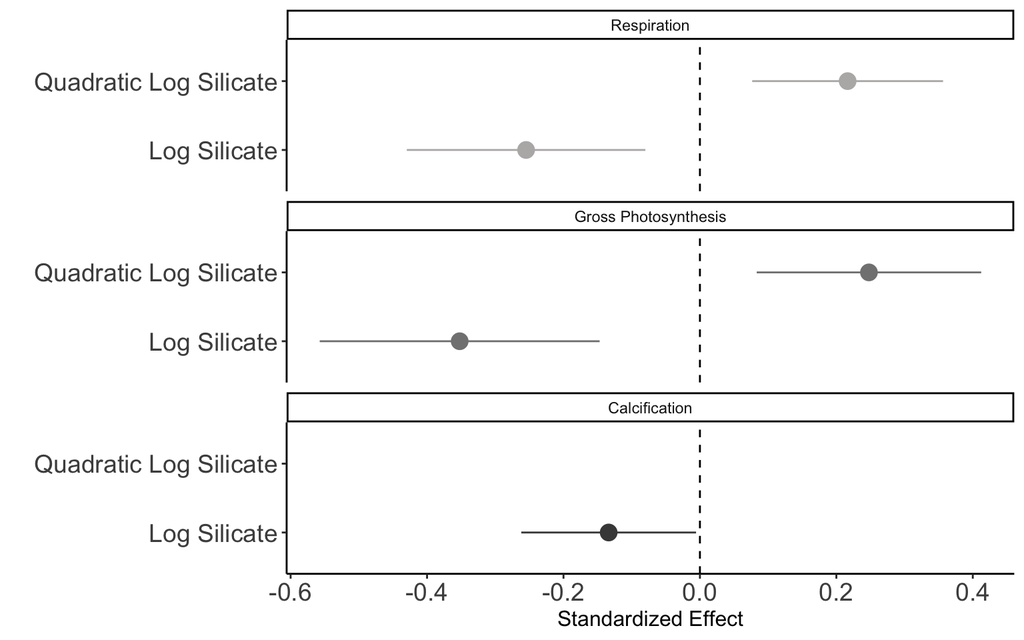

```r
### Put it all on the same plot though for comparison
### First need to extract the data from plot_model

R_std<-tibble(plot_model(modeltest_R, type = "std")$data) %>%
  mutate(Rate = "Respiration")

GP_std<-tibble(plot_model(modeltest_GP, type = "std")$data) %>%
  mutate(Rate = "Gross Photosynthesis")

C_std<-tibble(plot_model(modeltest_C, type = "std")$data) %>%
  mutate(Rate = "Calcification")

### Bind it all
all_std<-GP_std %>%
  bind_rows(R_std)%>%
  bind_rows(C_std)

### Plot a standardized effects with all three together
standardized_effects <- all_std %>%
#  filter(Rate=="Gross Photosynthesis") %>%
  mutate(term = case_when(term == "log_silicate"~ "Log Silicate",
                          term == "I(log_silicate^2)"~ "Quadratic Log Silicate")) %>% # Reverse the order of Rate
  mutate(Rate = factor(Rate, levels = c("Respiration","Gross Photosynthesis","Calcification"))) %>% # put the levels in an order I want for plotting
  ggplot(aes(x = estimate,
             y = term,
             color = Rate))+
  geom_vline(xintercept = 0, linetype = 2) +
  geom_point(size = 4,
             position = position_dodge(0.9)) + # dodge the points so not on top of each other
  geom_errorbar(aes(xmin = conf.low, xmax = conf.high), width = 0, position = position_dodge(0.9)) +
  scale_color_manual(values=c("#b8b5b5", "#838282", "#484747"),
                     guide="none") +
  facet_wrap(~Rate, nrow = 3) +
  labs(x = "Standardized Effect",
       y = "") +
  theme_classic() +
  theme(legend.text = element_text(size = 14),
        axis.text = element_text(size = 14),
        axis.title = element_text(size = 12))

standardized_effects
```

```r
ggsave(here::here("Outputs", "PaperFigures", "standardized_effects.jpg"),
       width=12, height=14)

#legend.position = c(0.3, 0.85)
```

## Respiration plot

```r
###############################
## create tibble for R data
###############################

R_newdata<-tibble(umol.cm2.hr = rep(seq(0,0.5,0.01),14), # min to max ranges from ~ 0 - 0.5. There are 14 colonies so repeat this sequence 14 times
                  log_silicate =rep(seq(0.5,3.5,0.06),14), # the min log Si is ~1 and the max is ~ 3.3- make a a sequence that is within that range that is the same length as the sequence for R
                  silicate = exp(log_silicate), # take the exponent of the log Si to get raw Si
                  new_colonynumber = c(rep(1,51),rep(2,51),rep(3,51),rep(4,51), # repeat each colony number the same size as the new silicate and umol data
                                       rep(5,51),rep(6,51),rep(7,51),rep(8,51),
                                       rep(13,51),rep(14,51),rep(15,51),rep(16,51),
                                       rep(17,51),rep(18,51)),
                  date = c(rep("6/17/23",51),rep("6/17/23",51),rep("6/17/23",51),rep("6/18/23",51), # make a date vector that alignes with each colony vector that is als the same length
                           rep("6/21/23",51),rep("6/21/23",51),rep("6/22/23",51),rep("6/22/23",51),
                           rep("6/10/23",51),rep("6/10/23",51),rep("6/11/23",51),rep("6/11/23",51),
                           rep("6/12/23",51),rep("6/12/23",51)),
                  site  = ifelse(new_colonynumber %in% 1:8, "Varari","Cabral")) # but in the site names

# create a color gradient for Varari
colfunc_V <- colorRampPalette(c("firebrick1", "firebrick4"))
Vcolors<-colfunc_V(8) # create 8 colors between the lightest and darkest firebrick

# create a color gradient for cabral
colfunc_c <- colorRampPalette(c("goldenrod1", "goldenrod4"))
Ccolors<-colfunc_c(6) # create 8 colors between the lightest and darkest goldenrod. There are only 6 Cabral corals


color_values<-c(Vcolors,Ccolors) # make a color value for everything together

##########################################
# create a new data frame that is the size of the prediction data frame
##########################################
plot_df_R <- tibble(silicate = R_newdata$silicate,
                    log_silicate = R_newdata$log_silicate,
                    pred_umol = predict(modeltest_R, newdata = R_newdata),
                    new_colonynumber = as.factor(R_newdata$new_colonynumber))

##########################################
# edits based on errors in simple predict function
##########################################

# Define a function for prediction
pred_fun <- function(fit) {
  predict(fit, newdata = PhysioRates_Wide, re.form = ~0)
}

# Bootstrapping to get standard errors (adjust 'nsim' for more precision)
boot_res <- bootMer(modeltest_R, pred_fun, nsim = 100) # Set nsim as needed

# Predictions from the original model
predictions <- predict(modeltest_R, newdata = PhysioRates_Wide, re.form = ~0)

# Standard errors from bootstrapping
se_fit <- apply(boot_res$t, 2, sd)

# Combine predictions and SEs into a tibble
predict_r <- tibble(fit = predictions, se = se_fit, silicate = PhysioRates_Wide$silicate_umolL)

# Output the tibble
predict_r
```

```
## # A tibble: 121 × 3
##      fit     se silicate
##    <dbl>  <dbl>    <dbl>
##  1 0.336 0.0282     3.38
##  2 0.336 0.0282     3.38
##  3 0.325 0.0280     4.24
##  4 0.325 0.0280     4.24
##  5 0.353 0.0290     2.58
##  6 0.353 0.0290     2.58
##  7 0.319 0.0280     4.88
##  8 0.319 0.0280     4.88
##  9 0.319 0.0280     4.88
## 10 0.332 0.0281     3.63
## # ℹ 111 more rows
```

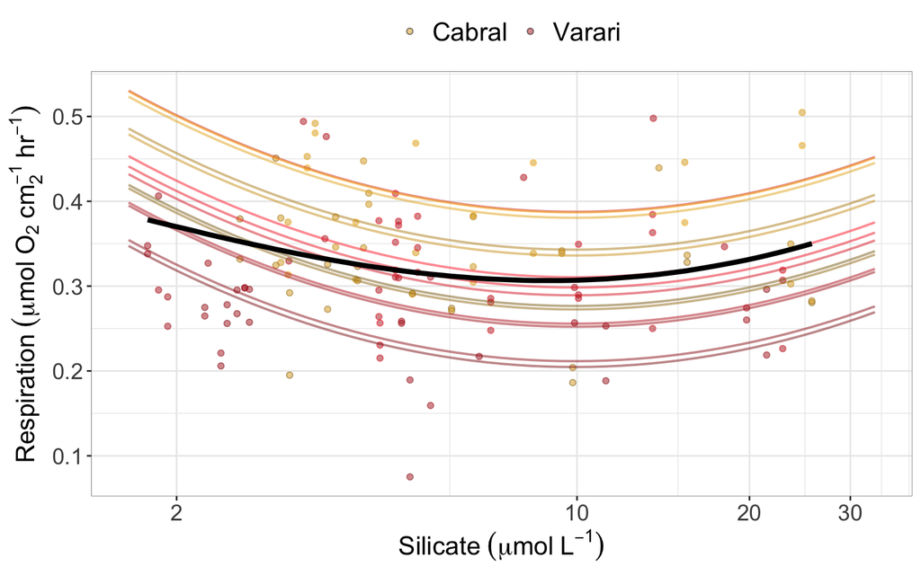

```r
##########################################
# make the plot
##########################################

Rplot<-ggplot() + # first plot the original data in the background and make it a bit transparent
  geom_point(data = R1,
             alpha = 0.5,
             aes(x= silicate_umolL,
                 y= Resp,
                 color = factor(new_colonynumber),
                 fill = site), # I added fill = site so that I can remove the colony number legend and just have one for site for ease of interpretation
             shape = 21 # this shape makes the color the border and fill the middle
  ) + # bring in the raw data first.  Because I wanted to show this on the raw scale I used raw silicate and then transformed it

   geom_line(data = plot_df_R, aes(x = silicate, # Make prediction lines this needs to be spelled the same as the plot dataframe with new data.. not your original one.
                                  y = pred_umol,
                                  color = new_colonynumber),
             linetype = 1, size = 0.7, show.legend = "FALSE", alpha=0.5) +
  coord_trans(x ="log") + # transform the axes
  scale_color_manual(values = color_values) + # add in the color values
  scale_fill_manual(values = c("goldenrod","firebrick"))+ # add in fill values for site
  scale_x_continuous(breaks = c(2,10,20,30)) +
  guides(color = "none") + # delete the guide for color
  geom_line(data = predict_r, aes(x = silicate, y = fit), color = "black", linewidth = 1.5) + # prediction for just fixed effect
 # geom_ribbon(data = predict_r, aes(x = silicate, ymin = fit-se, ymax = fit+se), alpha = 0.2, color = "grey")+
   labs(linetype = NULL,
       color = " ",
       fill = " ",
       x = expression(Silicate~(mu*mol~L^-1)),
       y = expression(Respiration~(mu*mol~O[2]~cm[2]^-1~hr^-1))) +
  theme_bw()+
  theme(legend.position = "top",
        legend.text = element_text(size = 16),
        axis.text = element_text(size = 14),
        axis.title = element_text(size = 16),
        plot.title = element_text(face = 2, hjust = 0.5),
        panel.border = element_rect(fill = NA, linewidth = 0.2))
Rplot
```

```r
# if you want to see what your random effects are
lme4::ranef(modeltest_R,condVar = TRUE)
```

```
## $new_colonynumber
##      (Intercept)
## 1   0.0110691980
## 2  -0.0010427014
## 3  -0.0102551644
## 4   0.0025463089
## 5   0.0009652726
## 6  -0.0026416844
## 7   0.0018897883
## 8  -0.0050282233
## 13  0.0043538155
## 14 -0.0018921909
## 15 -0.0029232586
## 16  0.0039767977
## 17 -0.0025519892
## 18  0.0015340311
##
## $date
##          (Intercept)
## 6/10/23  0.075943112
## 6/11/23  0.032502534
## 6/12/23 -0.031404831
## 6/17/23 -0.007054585
## 6/18/23  0.078555688
## 6/21/23 -0.051718660
## 6/22/23 -0.096823258
##
## $site
##          (Intercept)
## Cabral  1.588347e-09
## Varari -1.588347e-09
##
## with conditional variances for "new_colonynumber" "date" "site"
```

## Gross Photosynthesis plot

```r
###############################
## create tibble for GP data
## if have questions, see above section on Respiration for comments
###############################

GP_newdata <- tibble(umol.cm2.hr = rep(seq(0,1.5,0.01), each = 1, length.out = 714), # min to max ranges from ~ 0.18 - 1.4.
                  log_silicate =rep(seq(0.5,3.5,0.06),14),
                  silicate = exp(log_silicate),
                  new_colonynumber = c(rep(1,51),rep(2,51),rep(3,51),rep(4,51),
                                       rep(5,51),rep(6,51),rep(7,51),rep(8,51),
                                       rep(13,51),rep(14,51),rep(15,51),rep(16,51),
                                       rep(17,51),rep(18,51)),
                  date = c(rep("6/17/23",51),rep("6/17/23",51),rep("6/17/23",51),rep("6/18/23",51),
                             rep("6/21/23",51),rep("6/21/23",51),rep("6/22/23",51),rep("6/22/23",51),
                             rep("6/10/23",51),rep("6/10/23",51),rep("6/11/23",51),rep("6/11/23",51),
                             rep("6/12/23",51),rep("6/12/23",51)),
                  site  = ifelse(new_colonynumber %in% 1:8, "Varari","Cabral"))

# create a color gradient for Varari
colfunc_V <- colorRampPalette(c("firebrick1", "firebrick4"))
Vcolors<-colfunc_V(8)

# create a color gradient for cabral
colfunc_c <- colorRampPalette(c("goldenrod1", "goldenrod4"))
Ccolors<-colfunc_c(6)


color_values<-c(Vcolors,Ccolors)

##########################################
# create a new data frame that is the size of the prediction data frame
##########################################
plot_df_GP <- tibble(silicate = GP_newdata$silicate,
                    log_silicate = GP_newdata$log_silicate,
                    pred_umol = predict(modeltest_GP, newdata = GP_newdata),
                    new_colonynumber = as.factor(GP_newdata$new_colonynumber))

##########################################
# edits based on errors in simple predict function
##########################################

# Define a function for prediction
pred_funGP <- function(fit) {
  predict(fit, newdata = PhysioRates_Wide, re.form = ~0)
}

# Bootstrapping to get standard errors (adjust 'nsim' for more precision)
boot_resGP <- bootMer(modeltest_GP, pred_funGP, nsim = 100) # Set nsim as needed

# Predictions from the original model
predictionsGP <- predict(modeltest_GP, newdata = PhysioRates_Wide, re.form = ~0)

# Standard errors from bootstrapping
se_fitGP <- apply(boot_resGP$t, 2, sd)

# Combine predictions and SEs into a tibble
predict_GP <- tibble(fitGP = predictionsGP, se = se_fitGP, silicate = PhysioRates_Wide$silicate_umolL)

# Output the tibble
predict_GP
```

```
## # A tibble: 121 × 3
##    fitGP     se silicate
##    <dbl>  <dbl>    <dbl>
##  1 0.758 0.0307     3.38
##  2 0.758 0.0307     3.38
##  3 0.729 0.0311     4.24
##  4 0.729 0.0311     4.24
##  5 0.798 0.0341     2.58
##  6 0.798 0.0341     2.58
##  7 0.714 0.0321     4.88
##  8 0.714 0.0321     4.88
##  9 0.714 0.0321     4.88
## 10 0.748 0.0306     3.63
## # ℹ 111 more rows
```

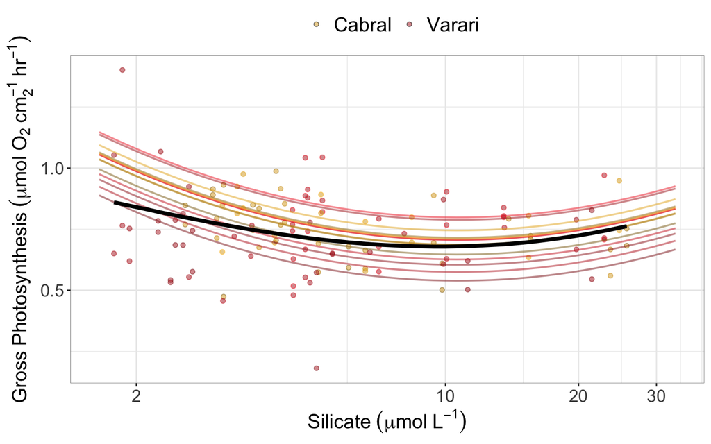

```r
##########################################
# make the plot
##########################################

GPplot <- ggplot() +
  geom_point(data = GP1,
             alpha = 0.5,
             aes(x= silicate_umolL,
                 y= GP,
                 color = factor(new_colonynumber),
                 fill = site),
             shape = 21) + # bring in the raw data first.
  geom_line(data = plot_df_GP, aes(x = silicate,
                                  y = pred_umol,
                                  color = new_colonynumber),
             linetype = 1, size = 0.7, show.legend = "FALSE", alpha=0.5) + ## made these prediction lines more transparent so main black line sticks out more
  coord_trans(x ="log") +
  scale_color_manual(values = color_values) +
  scale_fill_manual(values = c("goldenrod","firebrick"))+
  scale_x_continuous(breaks = c(2,10,20,30))+
  guides(color = "none") +
  geom_line(data = predict_GP, aes(x = silicate, y = fitGP), color = "black", linewidth = 1.5) + #moved here so that black line is ON TOP of raw data and predicted lines
  labs(linetype = NULL,
       color = " ",
       fill = " ",
       x = expression(Silicate~(mu*mol~L^-1)),
       y = expression(Gross~Photosynthesis~(mu*mol~O[2]~cm[2]^-1~hr^-1)) )+
  theme_bw()+
  theme(legend.position = "top",
        legend.text = element_text(size = 16),
        axis.text = element_text(size = 14),
        axis.title = element_text(size = 16),
        plot.title = element_text(face = 2, hjust = 0.5),
        panel.border = element_rect(fill = NA, linewidth = 0.2))


GPplot
```

```r
# if you want to see what your random effects are
lme4::ranef(modeltest_GP,condVar = TRUE)
```

```
## $new_colonynumber
##     (Intercept)
## 1   0.004869319
## 2   0.096137567
## 3   0.003998691
## 4  -0.042899950
## 5  -0.104645012
## 6   0.108668709
## 7  -0.041625585
## 8  -0.106594638
## 13  0.016916324
## 14  0.051187146
## 15  0.006198249
## 16  0.004744341
## 17  0.035878728
## 18 -0.032833889
##
## $date
##           (Intercept)
## 6/10/23  0.0150712946
## 6/11/23  0.0024215946
## 6/12/23  0.0006738229
## 6/17/23  0.0232377294
## 6/18/23 -0.0094937569
## 6/21/23  0.0008904439
## 6/22/23 -0.0328011285
##
## $site
##          (Intercept)
## Cabral  1.191259e-09
## Varari -1.191259e-09
##
## with conditional variances for "new_colonynumber" "date" "site"
```

## Calcification plot

```r
###############################
## create tibble for C data
###############################

C_newdata <- tibble(umol.cm2.hr = rep(seq(0,1.5,0.01), each = 1, length.out = 714),
  log_silicate = rep(seq(0.5,3.5,0.06), 14),
  silicate = exp(log_silicate),
  new_colonynumber = c(rep(1,51),rep(2,51),rep(3,51),rep(4,51),
                              rep(5,51),rep(6,51),rep(7,51),rep(8,51),
                              rep(13,51),rep(14,51),rep(15,51),rep(16,51),
                              rep(17,51),rep(18,51)),
  date = c(rep("6/17/23",51),rep("6/17/23",51),rep("6/17/23",51),rep("6/18/23",51),
           rep("6/21/23",51),rep("6/21/23",51),rep("6/22/23",51),rep("6/22/23",51),
           rep("6/10/23",51),rep("6/10/23",51),rep("6/11/23",51),rep("6/11/23",51),
           rep("6/12/23",51),rep("6/12/23",51)),
  site = ifelse(new_colonynumber %in% 1:8, "Varari", "Cabral"))

# create a color gradient for Varari
colfunc_V <- colorRampPalette(c("firebrick1", "firebrick4"))
Vcolors<-colfunc_V(8) # create 8 colors between the lightest and darkest firebrick

# create a color gradient for cabral
colfunc_c <- colorRampPalette(c("goldenrod1", "goldenrod4"))
Ccolors<-colfunc_c(6) # create 8 colors between the lightest and darkest goldenrod. There are only 6 Cabral corals


color_values<-c(Vcolors,Ccolors) # make a color value for everything together

##########################################
# create a new data frame that is the size of the prediction data frame
##########################################
plot_df_C <- tibble(silicate = C_newdata$silicate,
                    log_silicate = C_newdata$log_silicate,
                    pred_umol = predict(modeltest_C, newdata = C_newdata),
                    new_colonynumber = as.factor(C_newdata$new_colonynumber))

##########################################
# edits based on errors in simple predict function
##########################################

# Define a function for prediction
pred_funC <- function(fit) {
  predict(fit, newdata = PhysioRates_Wide, re.form = ~0)
}

# Bootstrapping to get standard errors (adjust 'nsim' for more precision)
boot_resC <- bootMer(modeltest_C, pred_funC, nsim = 100) # Set nsim as needed

# Predictions from the original model
predictionsC <- predict(modeltest_C, newdata = PhysioRates_Wide, re.form = ~0)

# Standard errors from bootstrapping
se_fitC <- apply(boot_resC$t, 2, sd)

# Combine predictions and SEs into a tibble
predict_C <- tibble(fitC = predictionsC, se = se_fitC, silicate = PhysioRates_Wide$silicate_umolL)

# Output the tibble
predict_C
```

```
## # A tibble: 121 × 3
##      fitC     se silicate
##     <dbl>  <dbl>    <dbl>
##  1 0.107  0.0211     3.38
##  2 0.107  0.0211     3.38
##  3 0.103  0.0206     4.24
##  4 0.103  0.0206     4.24
##  5 0.111  0.0218     2.58
##  6 0.111  0.0218     2.58
##  7 0.0999 0.0204     4.88
##  8 0.0999 0.0204     4.88
##  9 0.0999 0.0204     4.88
## 10 0.105  0.0209     3.63
## # ℹ 111 more rows
```

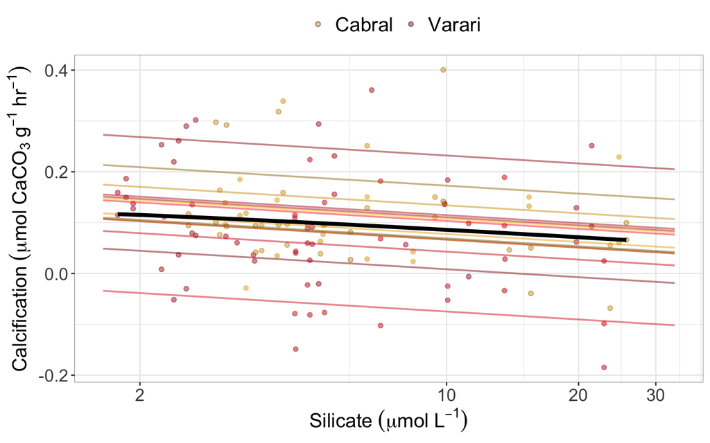

```r
##########################################
# make the plot
##########################################

Cplot<-ggplot() + # first plot the original data in the background and make it a bit transparent
  geom_point(data = C1,
             alpha = 0.5,
             aes(x= silicate_umolL,
                 y= C,
                 color = factor(new_colonynumber),
                 fill = site),
             shape = 21) + # bring in the raw data first.
  geom_line(data = plot_df_C, aes(x = silicate, # Make prediction lines, this should be with new data.. not original one.
                                  y = pred_umol,
                                  color = new_colonynumber),
             linetype = 1, size = 0.7, show.legend = "FALSE", alpha=0.5) +
  coord_trans(x ="log") + # transform the axes
  scale_color_manual(values = color_values) +
  scale_fill_manual(values = c("goldenrod","firebrick")) +
  scale_x_continuous(breaks = c(2,10,20,30))+
  guides(color = "none") + # delete the guide for color
  geom_line(data = predict_C, aes(x = silicate, y = fitC), color = "black", linewidth = 1.5) + # prediction for just fixed effect
  labs(linetype = NULL,
       color = " ",
       fill = " ",
       x = expression(Silicate~(mu*mol~L^-1)),
       y = expression(Calcification~(mu*mol~CaCO[3]~g^-1~hr^-1))) +
  theme_bw()+
  theme(legend.position = "top",
        legend.text = element_text(size = 16),
        axis.text = element_text(size = 14),
        axis.title = element_text(size = 16),
        plot.title = element_text(face = 2, hjust = 0.5),
        panel.border = element_rect(fill = NA, linewidth = 0.2))


Cplot
```

```r
# if you want to see what your random effects are
lme4::ranef(modeltest_C,condVar = TRUE)
```

```
## $new_colonynumber
##    (Intercept)
## 1   0.01539075
## 2  -0.02139016
## 3  -0.16276677
## 4  -0.04501414
## 5   0.02676004
## 6   0.02251789
## 7   0.14409869
## 8  -0.07962948
## 13  0.01979439
## 14 -0.01034052
## 15  0.04607498
## 16 -0.02141913
## 17  0.08479529
## 18 -0.01887182
##
## $date
##         (Intercept)
## 6/10/23           0
## 6/11/23           0
## 6/12/23           0
## 6/17/23           0
## 6/18/23           0
## 6/21/23           0
## 6/22/23           0
##
## $site
##        (Intercept)
## Cabral           0
## Varari           0
##
## with conditional variances for "new_colonynumber" "date" "site"
```

## Bring three plots together

- commented because does not knit otherwise
- on 5/14/2025, some R Studio update no longer works with code below… need to use “ggplot_add()” function?

```r
#combined_plots <- (Rplot + GPplot)/(Cplot + standardized_effects)

#combined_plots
#ggsave(here::here("Outputs", "PaperFigures", "Figure2_Physio_SEP.jpg"),
     #  width=13, height=10)
```

## Supplementary Figure 2

### Plot how many corals are net calcifying vs net dissolving

- this is supplementary figure used as additional evidence to show difference in Varari gw vs Cabral
- Results: more fragments in Varari were net dissolving compared to Cabral (and at lower dilutions)

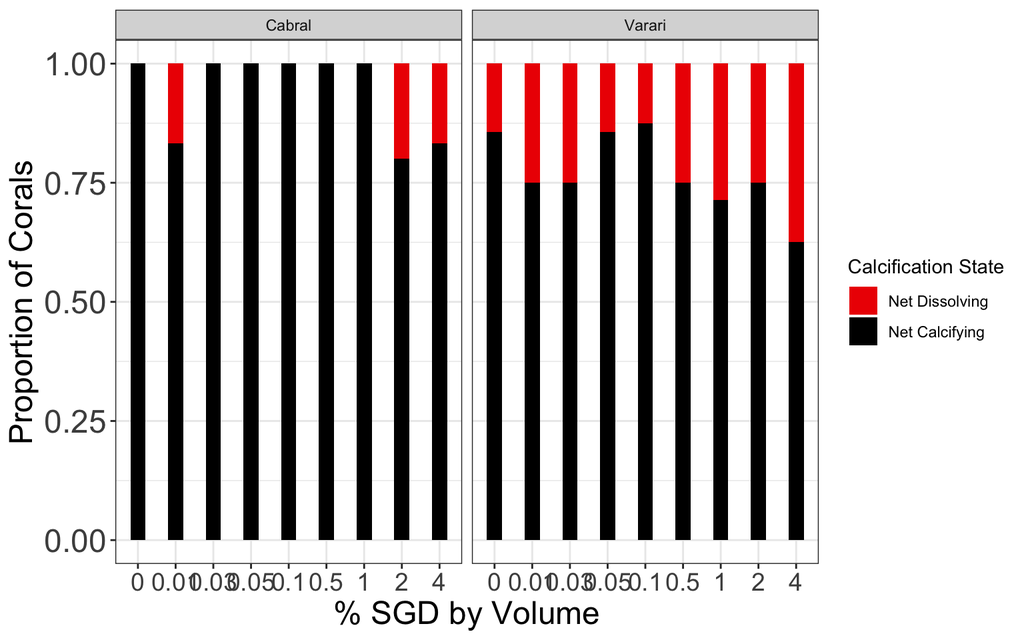

```r
dissolv_calcifplot <- RespoR_Normalized_Full_withNEC_nutrients %>%
  filter(P_R=="C") %>%
  filter(!is.infinite(umol.cm2.hr)) %>%
  dplyr::select(!c("phosphate_umolL":"TA_initial", "salinity", "date")) %>%
  mutate(rate_category = ifelse(umol.cm2.hr > 0, "positive", "negative")) %>%
  group_by(SGD_number, site) %>%
  dplyr::summarize(positive_count = sum(rate_category == "positive"),
            negative_count = sum(rate_category == "negative"))
dissolv_calcifplot2 <- dissolv_calcifplot %>%
  pivot_longer(cols = c(positive_count, negative_count),
               names_to = "rate_category",
               values_to = "count") %>%
  mutate(total_count = sum(count),
         proportion = count / total_count)

## plot
Net_CalcvsDissolution2 <- dissolv_calcifplot2 %>%
  ggplot(aes(x=as.factor(SGD_number),
             y=proportion,
             fill=rate_category)) +
  geom_bar(stat = "identity", position = "fill", width=0.4) +
  scale_fill_manual(values=c("red2", "black"),
                    labels = c("positive_count" = "Net Calcifying", "negative_count" = "Net Dissolving")) +
  theme_bw() +
  facet_wrap(~site) +
  labs(x = "% SGD by Volume",
       y = "Proportion of Corals",
       fill = "Calcification State") +
   theme(axis.text.x=element_text(size=14),
        axis.text.y=element_text(size=18),
        axis.title.x=element_text(size=18),
        axis.title.y=element_text(size=18),
        plot.title=element_text(hjust=0.5, ## centers title
                                size=20))

Net_CalcvsDissolution2
```

```r
ggsave(here::here("Outputs", "PaperFigures", "NetCalcifying_NetDissolving.jpg"),
       width = 11, height=7)
```